# Milestone Report

mphilip9

March 31, 2019

## Predicting the MIP award winner

**Problem**: The NBA is a sports league on the rise. It has a growing fanbase overseas (a professional league is currently being established in Africa with the help of the NBA), and since it lacks the stigma of CTE, it appears poised to steal some of the market share away from the NFL. There are a number of awards given out at the end of each season for various accomplishments, including the most improved player award (MIP). This award is given to the player who has shown the most progress during the regular season. Typically this means players that greatly increased their counting stats compared to their previous seasons in addition to overall player development.

**Who would care about this?**: Sportwriters are the ones who vote for the award, and so are likely to be interested in seeing who the likely winners are, statistically speaking. Since there are so many different counting stats and a number of advanced statistics regarding playerse in the league, there are a number of fans who obsess over the numbers surrounding the game. Meaning sports analysts would be wise to base their speculation on statistics. Besides the media, sports betting agencies will want to be able to track a player’s probability for winning the award in order to place the proper odds on the bet.

**Data Sources**: The data was pulled from a data-set on Kaggle, which in turned was scraped from *Basketball-reference* (https://www.kaggle.com/drgilermo/nba-players-stats/version/2). This data set contains player statistics from the past 67 seasons with 53 attributes, as well as some player information like the college team they played for and their home town. Another table was created from data for the award candidates, which was gathered from *Basketball-reference*.

**Problem Solution**: In order to predict the award winner, building a logistic regression algorithm is likely the best approach. This algorithm will classify each input as either a MIP award winner or Not a MIP award winner, and it will give the probability for both classes.

## Data Wrangling/Cleanup

Data wrangling was performed using the tidyr and dplyr packages. New variables (MPG and PPG) were added to the player statistics data frame, and all player data prior to 1985 was removed. The award was initiated the year before so all previous seasons did not have a MIP candidate, which could effect the predictive model. Also, a number of stats like turnovers and three point shots (the three pointer was even introduced until 79-80) were not tracked until the 1979-80 season. The two tables (player statistics and MIP candidates) were altered to match one another and then joined. NA values in the newly created MIP candidate column were converted to non-MIP. Blank columns were removed from the newly formed table. After reviewing MIP candidate mins and maxes, it was noticed that Dan Dickau had three MIP candidate seasons, all in 2005. The two rows with incomplete season stats were removed. New variables dipsplaying the differences in all player statistics for the previous year were created. Here is a sample of the code used for that purpose

> MIP <- MIP %>% arrange(Player, Year) %>% mutate(dif_PPG = ifelse(Player == lag(Player), PPG - lag(PPG), 0))

Following the creation of these new variables, NA values for players in the year 1985 were replaced with zeros. Here is a summary of the cleaned up table

```
##        X1            Year              Player              Pos
##  Min.   : 7559   Length:17098       Length:17098       Length:17098
##  1st Qu.:11843   Class :character   Class :character   Class :character
##  Median :16126   Mode  :character   Mode  :character   Mode  :character
##  Mean   :16126
##  3rd Qu.:20409
##  Max.   :24690
##       Age             Tm                  G               GS
##  Min.   :18.00   Length:17098       Min.   : 1.00   Min.   : 0.00
##  1st Qu.:24.00   Class :character   1st Qu.:25.00   1st Qu.: 0.00
##  Median :26.00   Mode  :character   Median :53.00   Median : 8.00
##  Mean   :26.92                      Mean   :48.95   Mean   :23.38
##  3rd Qu.:30.00                      3rd Qu.:74.00   3rd Qu.:45.00
##  Max.   :44.00                      Max.   :85.00   Max.   :83.00
##        MP            PER             TSperc          ThreePAr
##  Min.   :   0   Min.   :-90.60   Min.   :0.0000   Min.   :0.0000
##  1st Qu.: 299   1st Qu.:  9.60   1st Qu.:0.4710   1st Qu.:0.0060
##  Median : 958   Median : 12.60   Median :0.5160   Median :0.0905
##  Mean   :1145   Mean   : 12.37   Mean   :0.5013   Mean   :0.1718
##  3rd Qu.:1863   3rd Qu.: 15.60   3rd Qu.:0.5510   3rd Qu.:0.3080
##  Max.   :3533   Max.   :129.10   Max.   :1.1360   Max.   :1.0000
##       FTr            ORBperc           DRBperc          TRBperc
##  Min.   :0.0000   Min.   :  0.000   Min.   :  0.00   Min.   :  0.000
##  1st Qu.:0.1930   1st Qu.:  2.400   1st Qu.:  9.10   1st Qu.:  6.000
##  Median :0.2840   Median :  5.100   Median : 12.80   Median :  9.100
##  Mean   :0.3167   Mean   :  6.092   Mean   : 13.83   Mean   :  9.961
##  3rd Qu.:0.3940   3rd Qu.:  8.900   3rd Qu.: 18.10   3rd Qu.: 13.400
##  Max.   :6.0000   Max.   :100.000   Max.   :100.00   Max.   :100.000
##     ASTperc          STLperc          BLKperc          TOVperc
##  Min.   :  0.00   Min.   : 0.000   Min.   : 0.000   Min.   :  0.00
##  1st Qu.:  6.20   1st Qu.: 1.100   1st Qu.: 0.400   1st Qu.: 11.10
##  Median : 10.20   Median : 1.500   Median : 0.900   Median : 13.90
##  Mean   : 13.05   Mean   : 1.647   Mean   : 1.481   Mean   : 14.77
##  3rd Qu.: 17.80   3rd Qu.: 2.100   3rd Qu.: 2.000   3rd Qu.: 17.30
##  Max.   :100.00   Max.   :24.200   Max.   :77.800   Max.   :100.00
##     USGperc            OWS              DWS               WS
##  Min.   :  0.00   Min.   :-3.300   Min.   :-1.000   Min.   :-2.100
##  1st Qu.: 15.30   1st Qu.: 0.000   1st Qu.: 0.200   1st Qu.: 0.200
##  Median : 18.60   Median : 0.400   Median : 0.800   Median : 1.300
##  Mean   : 18.86   Mean   : 1.213   Mean   : 1.158   Mean   : 2.372
```

[output cut: 99 more lines]

```
##  Max.   : 223.0000   Max.   : 1.000000   Max.   : 747.000
##     dif_STL            dif_BLK          dif_USGperc
##  Min.   :-191.000   Min.   :-265.000   Min.   :-67.8000
##  1st Qu.: -13.000   1st Qu.:  -6.000   1st Qu.: -1.7000
##  Median :   0.000   Median :   0.000   Median :  0.0000
##  Mean   :  -1.755   Mean   :  -1.339   Mean   : -0.1966
##  3rd Qu.:   8.000   3rd Qu.:   3.000   3rd Qu.:  1.3000
##  Max.   : 199.000   Max.   : 254.000   Max.   : 71.2000
##   dif_TOVperc          dif_BLKperc         dif_STLperc
##  Min.   :-100.00000   Min.   :-76.10000   Min.   :-22.80000
##  1st Qu.:  -1.60000   1st Qu.: -0.30000   1st Qu.: -0.30000
##  Median :   0.00000   Median :  0.00000   Median :  0.00000
##  Mean   :  -0.03603   Mean   : -0.02953   Mean   : -0.01329
##  3rd Qu.:   1.50000   3rd Qu.:  0.20000   3rd Qu.:  0.20000
##  Max.   : 100.00000   Max.   : 58.30000   Max.   : 13.80000
```

## Statistical analysis and data visualization

Before visualizing the difference between MIP and non-MIP candidates in plots, the means for some of the statistics were viewed in a simple table, like so:

```
## # A tibble: 2 x 2
##   MIP_Candidate meandif_PPG
##   <chr>               <dbl>
## 1 1                   5.85
## 2 Not_MIP            -0.253
```

Players who played less than 23 minutes per game were initially removed to better visualize the difference (as this was the minumum a MIP candidate played), but this data was kept for the regression model.

Below is a simple line plot to depict the positive correlation between PPG and MPG. This is essentially true for all statistics. More playing time means more chances to score/steal/etc. It also typically means the player is better as well. This was before the minute parameter was implemented.

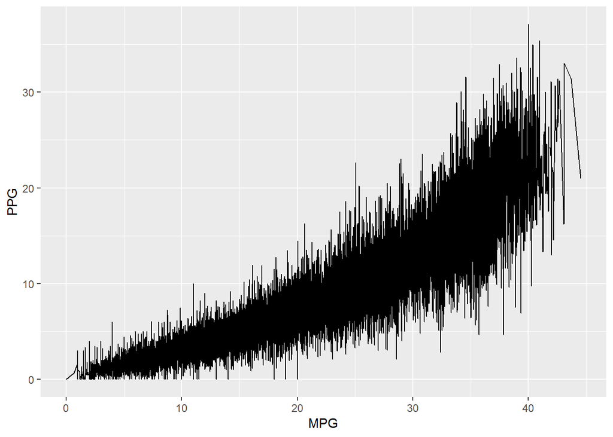

Here is a histogram depicting the frequency of PPG seasons (50 bins).

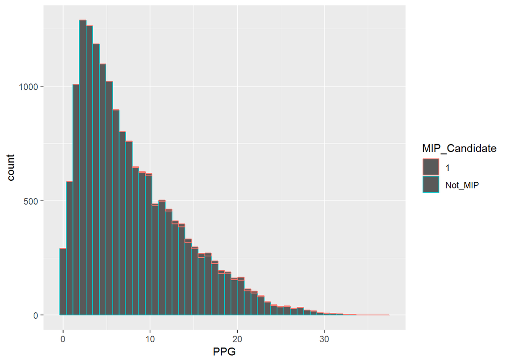

You can see that the average for MIP candidates is higher than the average for Non-candidate players, although it is hard to visualize. To make the comparison between MIP and non-MIP candidates clearer, players with fewer than 23 MPG and 55 G (games played) and players before 1985 were removed. 23 MPG was the minimum amount played for a MIP candidate, and 1985 was chosen because it was one year before the introduction of the award. 55 games played was chosen to remove players with limited data and extremely unlikely to be considered for the award. Below is the same plot but from the altered table.

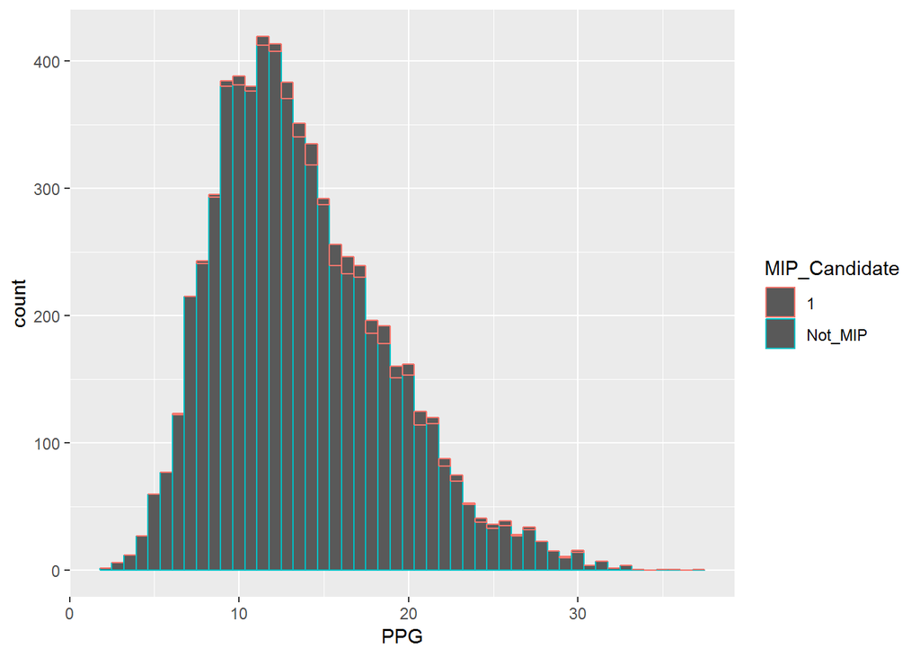

Below is a scatter plot graphing PPG vs MPG for MIP and non-MIP candidates. There doesn’t appear to be a discernible trend for MIP vs non-MIP (although this is partly due to overcrowding).

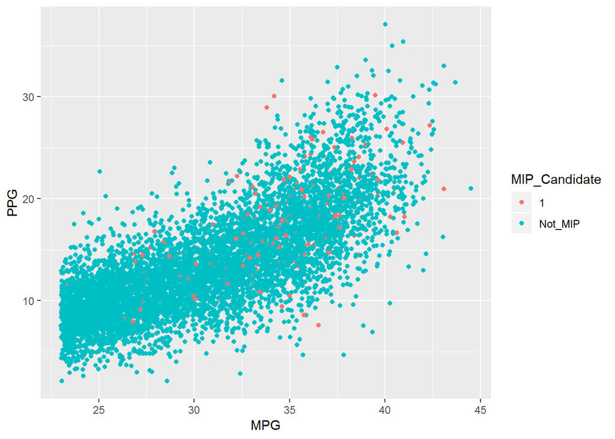

And here is a jittered scatter plot showing the difference in PPG with a color gradient depicting MPG. This does a slightly better job of depicting the difference between the two types. But a more obvious trend can be seen when looking at the difference in a players statistics from the previous season.

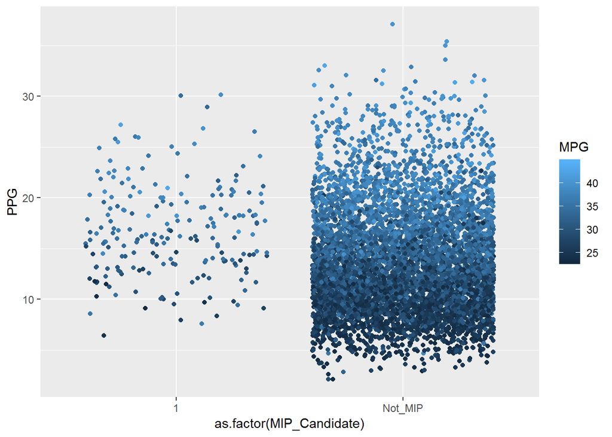

The plot below graphs the difference in PPG vs the difference in MPG. The overall trend is very pronounced here as well as the differences between the two groups.

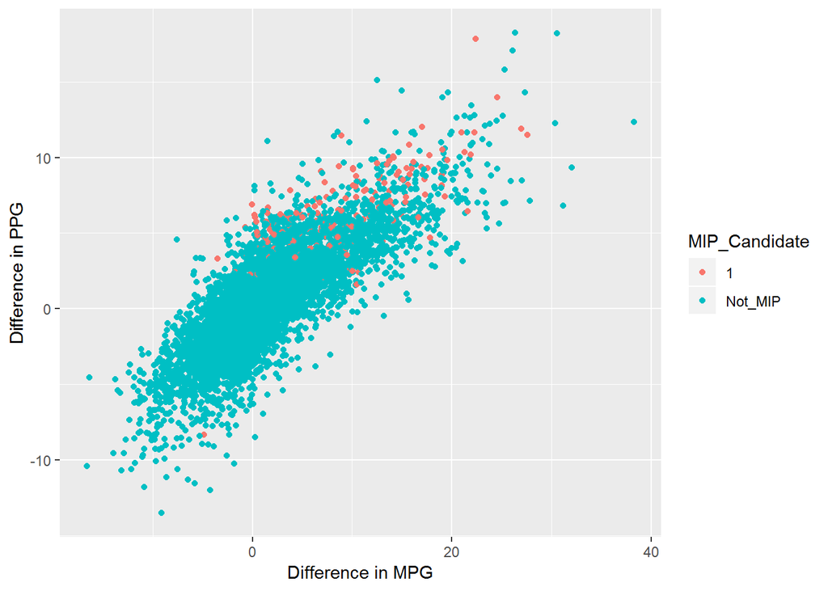

Out of all the newly created variables, difference in VORP and PPG appear the most significant.

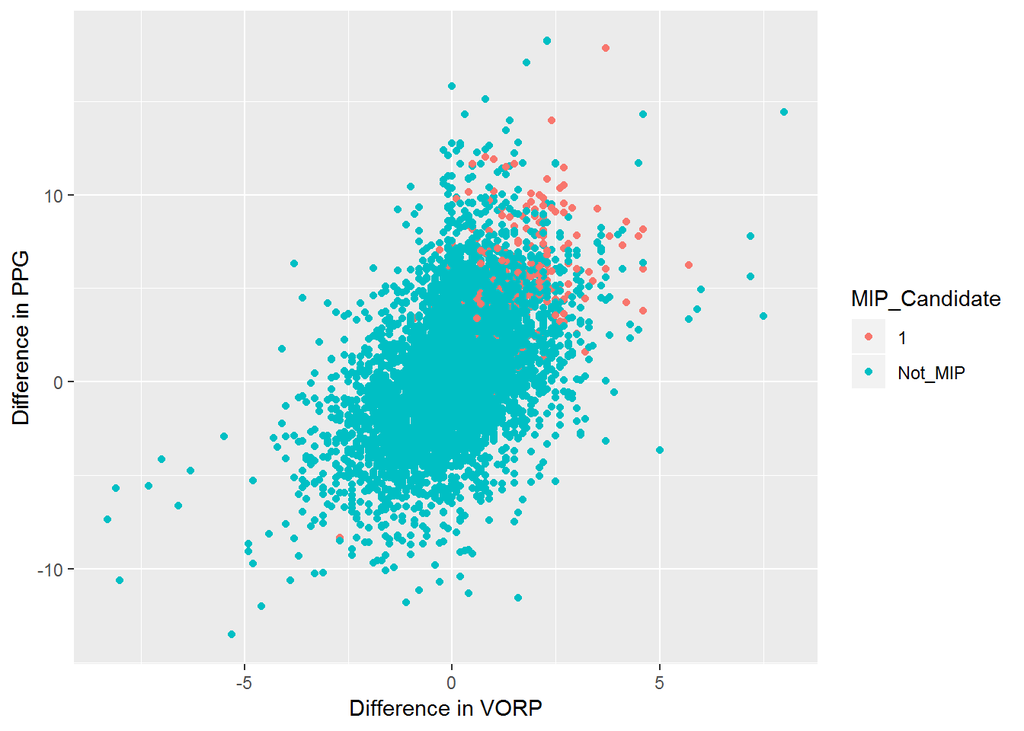